## Local marine diversity change meta-analysis model results

### Duration analysis

To test whether local marine species richness has changed over time, we performed a meta-regression on the relationship between the log ratio of species richness between the final and initial time points and study duration. On average, we observed an effect size of 0.01, which corresponds to a gain in species richness at a rate of 1.05 % per year (Table 1).

**Table 1.** Parameter estimates from a variance-weighted meta-regression of the log ratio of the proportion of species richness change (LR) over study duration (D). For each parameter estimate the standard error (se), p-value (pval), lower (ci.lb) and upper (ci.ub) 95% confidence intervals, number of sites (k) and number of studies (n) is included. The percent change (% change) has been back-calculated from the estimated log ratio of the proportion of change in species richness. Each study could contain multiple sites and therefore studies were modeled as random effects.

| model | parameter | estimate | % change | se | pval | ci.lb | ci.ub | k | n |
| --- | --- | --- | --- | --- | --- | --- | --- | --- | --- |
| LR ~ D | intrcpt | -0.047 | -4.59 | 0.057 | 0.412 | -0.159 | 0.065 | 148 | 36 |
| LR ~ D | Duration | 0.010 | 1.05 | 0.005 | 0.035 | 0.001 | 0.020 | 148 | 36 |

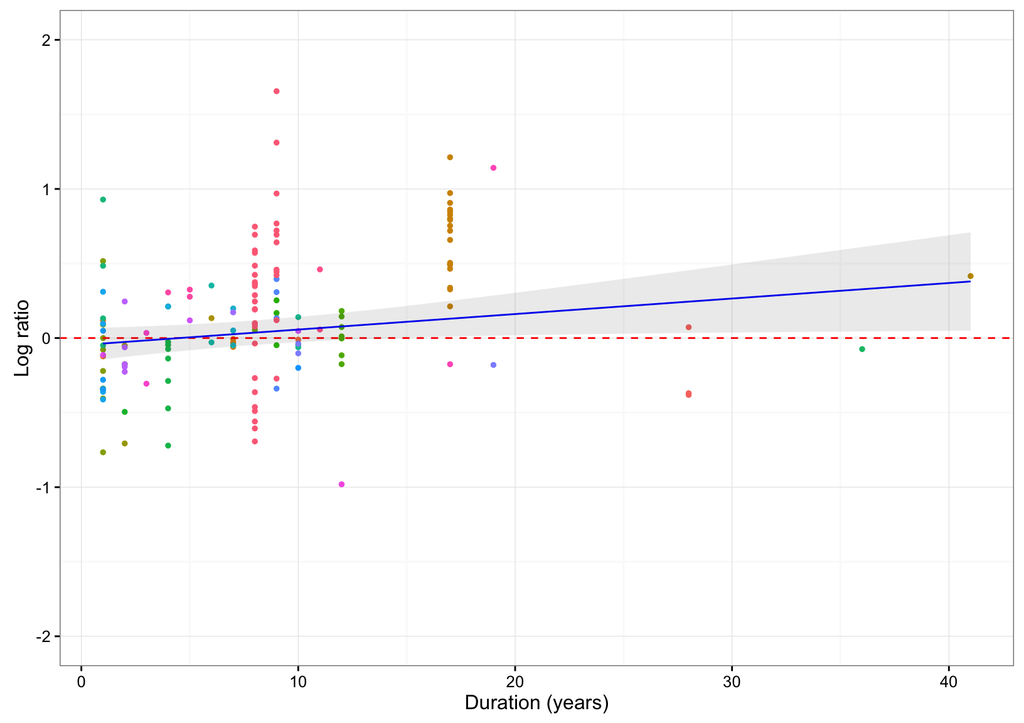

**Figure 1.** Variance-weighted meta-regression shows an increase in the log ratio of species richness change over time at a rate of species richness gain of 1% per year. Studies could contain data from multiple sites and so studies were modelled as random effects.

### Cumulative human impacts model

When cumulative impacts were included in the model, there was an average rate of change per year in the log proportion of species of -0.033 -0.033, which is equivalent to an annual rate of species loss of -3.24% across sites (Table 2). While cumulative impact values alone did not predict species richness change in the short term, over the long term (impact * duration interaction), each unit increase in cumulative impact value decreased the rate of species loss per year by 0.86% / (year * impact score) (Table 2, Fig. 2).

Predictions from this model that includes cumulative human impacts show that when cumulative impacts are low, there is a signal of species loss over 15 years (Figs 3 and 4). At intermediate levels of human impact (25th and 50th impact quantiles observed in our data), human impacts alter the rate of change of species richness and produce predictions where no net change is observed over 15 years (Figs 3 and 4). Meanwhile high cumulative impacts (maximum value observed in our data) predict species gains over the long term. However, even when human impacts are high, gains are not predicted to be observed in studies shorter than eight years (Figs 3 and 4).

**Table 2.** Parameter estimates from a variance-weighted meta-regression of the relationship between the log ratio of the proportion of species richness change (LR), study duration (D), cumulative human impact value (Imp, Halpern et al. 2015), and the interaction of study duration and cumulative human impact value (D * Imp). For each parameter estimate the standard error (se), p-value (pval), lower (ci.lb) and upper (ci.ub) 95% confidence intervals, number of sites (k) and number of studies (n) is included. The percent change (% change) has been back-calculated from the parameter estimates of the log ratio of the proportion of change in species richness. Each study could contain multiple sites and therefore studies were modeled as random effects.

| model | parameter | estimate | % change | se | pval | ci.lb | ci.ub | k | n |
| --- | --- | --- | --- | --- | --- | --- | --- | --- | --- |
| LR ~ Imp + D + D*Imp | intrcpt | 0.202 | 22.42 | 0.133 | 0.129 | -0.059 | 0.464 | 136 | 33 |
| LR ~ Imp + D + D*Imp | Duration | -0.033 | -3.24 | 0.011 | 0.004 | -0.055 | -0.011 | 136 | 33 |
| LR ~ Imp + D + D*Imp | Impact | -0.047 | -4.62 | 0.027 | 0.080 | -0.100 | 0.006 | 136 | 33 |
| LR ~ Imp + D + D*Imp | Duration:Impact | 0.009 | 0.86 | 0.002 | 0.000 | 0.005 | 0.013 | 136 | 33 |

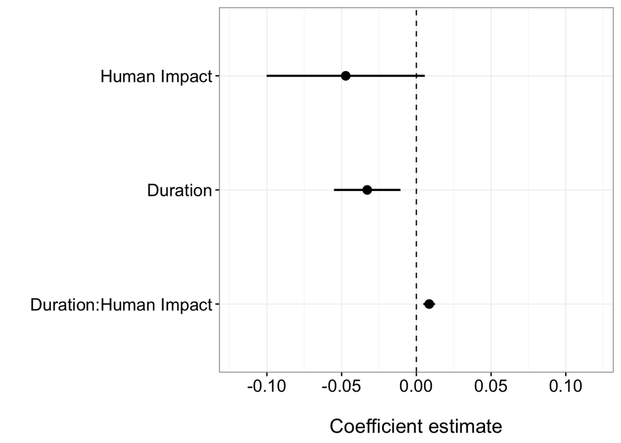

**Figure 2.** Coefficient estimates for the relationship of the log-proportion of change in species richness over time, as moderated by cumulative human impacts (Halpern et al 2015). Points represent coefficient estimates and lines represent 95% CI obtained using a variance-weighted meta-regression.

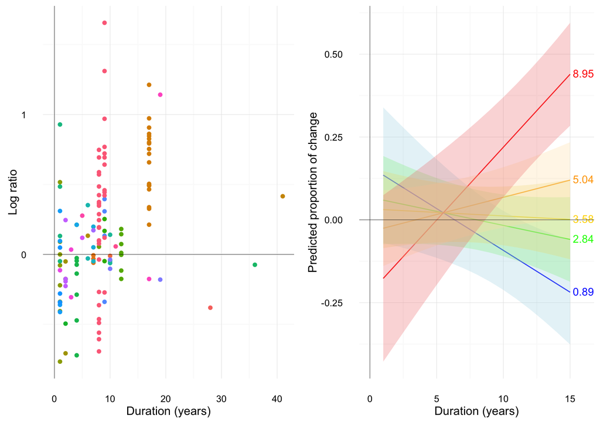

**Figure 3.** Observed log response ratios of proportion of species richness change over 41 years (left) and predicted log response ratios of species richness change over 15 years (right) as moderated by five quantiles of cumulative human impacts observed in our dataset: q0 = 0.89 (blue), q25 = 2.84 (green), q50 = 3.58 (yellow), q75 = 5.04 (orange), q100 = 8.95 (red). Predicted log response ratios are presented for only 15 years, because less than 15% of studies represent durations longer than 15 years (Fig. S2)

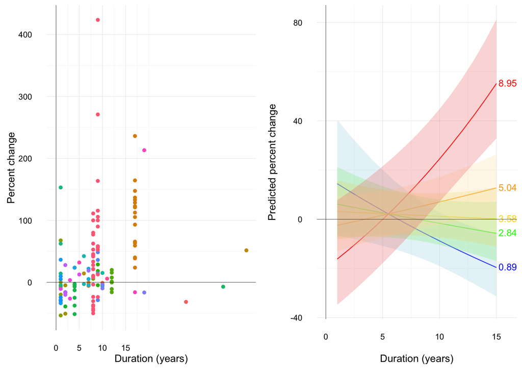

**Figure 4.** Observed percent change in species richness over 41 years (left) and predicted percent change of species richness change over 15 years (right) as moderated by five quantiles of cumulative human impacts observed in our dataset: q0 = 0.89 (blue), q25 = 2.84 (green), q50 = 3.58 (yellow), q75 = 5.04 (orange), q100 = 8.95 (red). Predicted log response ratios are presented for only 15 years, because less than 15% of studies represent durations longer than 15 years (Fig. S2).

#### Our results in the global context of cumulative human impacts

Globally the impact values range from 0 to >15. In our analysis, these impact values ranged between 0.8905841 - 8.9488406

Fifty percent of our studies have cumulative human impact values between 2.8 and 5.1. This analysis highlights how biases in our sampling of local communities can obscure effects of human impacts on local scale species richness change. If this sampling is representative of studies used in previous analyses, they do not represent the spread of human impacts affecting marine communities.

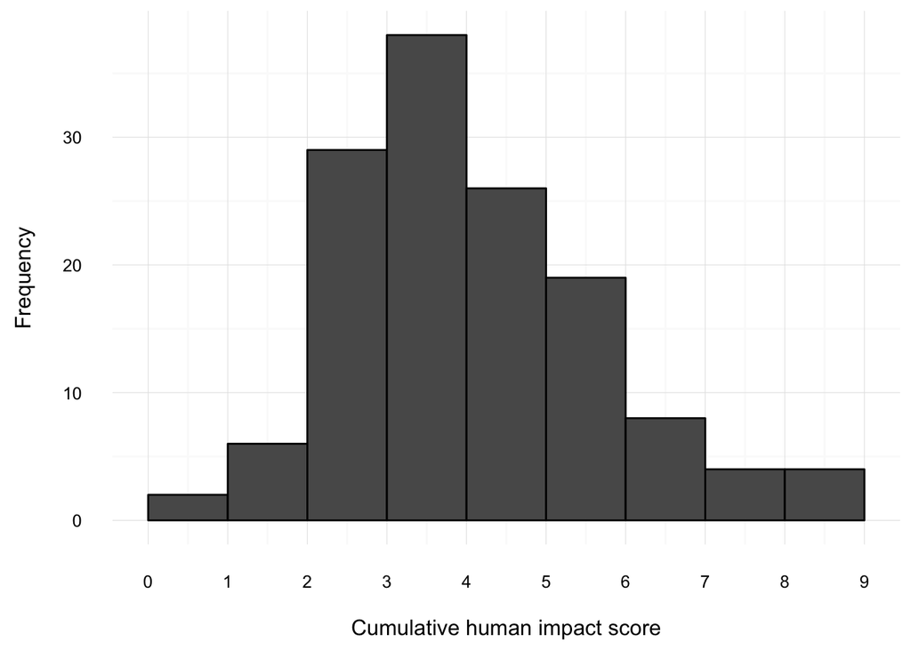

**Figure 5.** Frequency distribution of cumulative human impacts across the data used for the variance-weighted meta-regression

### Specific drivers model

Accounting for cumulative human impact values suggests that, as expected, species richness changes are context dependent. These results suggest that human impacts moderate the rate at which species richness changes. However, the cumulative human impact values summarise 19 different human impacts in marine ecosystems (Halpern et al. 2015). We ask whether the direction and magnitude of local species richness change can be more specifically attributed to three primary global drivers of diversity change. In particular, temperature change, nutrient addition, and species invasions are three drivers that have been associated with changes in local communities (Murphy and Romanuk 2014, …) and are three of the data layers that have been included in the calculation of cumulative human impact values. We have used the invasion potential (quantified using global shipping tonnage as a proxy for propagule pressure) and nutrient addition data layers aggregated by Halpern et al. (2015) in our analysis, in addition to the decadal rate of linear temperature change calculated using the Hadley Met Centre sea surface temperature data.

**Table 3.** Standardised coefficient estimates from a variance-weighted meta-regression of the relationship between the log ratio of the proportion of species richness change (LR), study duration (D), and three drivers of biodiversity change: invasion potential (I), nutrient addition (N), and linear temperature change (LTC). To test how these three drivers affect the rate of change of species richness we included interactions between study duration and these three drivers. For each parameter estimate the standard error (se), p-value (pval), lower (ci.lb) and upper (ci.ub) 95% confidence intervals, number of sites (k) and number of studies (n) is included. The percent change (% change) has been back-calculated from the estimated log ratio of the proportion of change in species richness using raw (unscaled) predictor values. The units of this percent change are for each unit of driver impact level, except for the invasion potential, where the percent change is for each 10^3 increase in impact level. Each study could contain multiple sites and therefore studies were modeled as random effects.

| model | parameter | estimate | % change | se | pval | ci.lb | ci.ub | k | n |
| --- | --- | --- | --- | --- | --- | --- | --- | --- | --- |
| LR ~ D * (I + N + LTC) | intrcpt | -0.165 | -3.14 | 0.135 | 0.221 | -0.430 | 0.099 | 114 | 24 |
| LR ~ D * (I + N + LTC) | Duration | 0.024 | 1.60 | 0.009 | 0.010 | 0.006 | 0.043 | 114 | 24 |
| LR ~ D * (I + N + LTC) | Inv | -1.475 | -1.38 | 0.818 | 0.071 | -3.078 | 0.129 | 114 | 24 |
| LR ~ D * (I + N + LTC) | LTC | 0.133 | 5.33 | 0.060 | 0.027 | 0.015 | 0.250 | 114 | 24 |
| LR ~ D * (I + N + LTC) | Nut | 0.750 | 1.30 | 0.281 | 0.008 | 0.199 | 1.301 | 114 | 24 |
| LR ~ D * (I + N + LTC) | Duration:Inv | 0.129 | 0.12 | 0.055 | 0.019 | 0.021 | 0.237 | 114 | 24 |
| LR ~ D * (I + N + LTC) | Duration:LTC | -0.058 | -2.25 | 0.031 | 0.059 | -0.118 | 0.002 | 114 | 24 |
| LR ~ D * (I + N + LTC) | Duration:Nut | -0.109 | -0.19 | 0.039 | 0.005 | -0.186 | -0.033 | 114 | 24 |

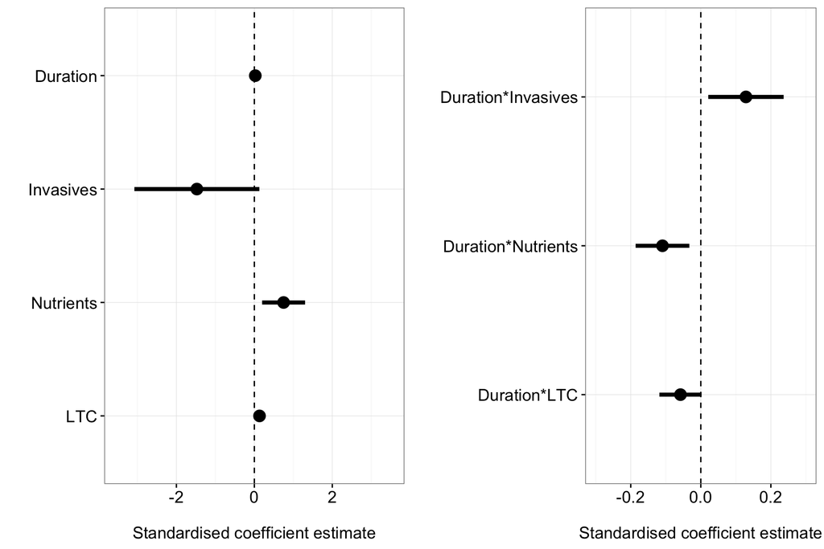

**Figure 6.** The relationship of the log-proportion of change in species richness over time, as moderated by three drivers of global change, invasives (propagule pressure), nutrient addition, and LTC (the decadal rate of linear temperature change). Points represent standardised coefficient estimates and lines represent 95% CI obtained using a variance-weighted meta-regression.

#### Predictions from the multiple drivers model

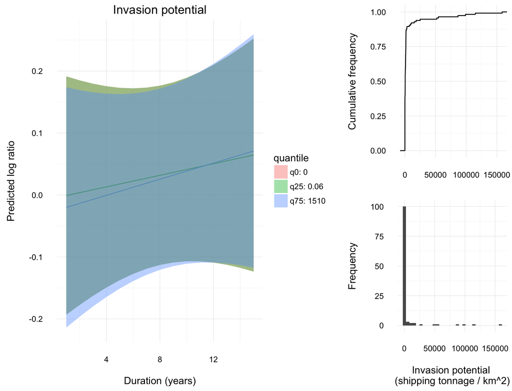

**Figure 7.** Predicted change in the log-proportion of change in species richness over time as moderated by invasion potential over 15 years (Left). Predictions were obtained using a variance-weighted meta-regression from the full drivers model: LR ~ Duration * (invasion potential + nutrient addition + linear temperature change). Nutrient addition and linear temperature change were held constant at the median values of these two drivers found observed in our dataset. Shaded areas represent 95% confidence intervals. Cumulative frequency distributions (top right) and frequency histograms (bottom right) invasion potential values observed in the data used for the variance-weighted meta-regression. Shipping tonnage was used as a proxy for invasion potential.

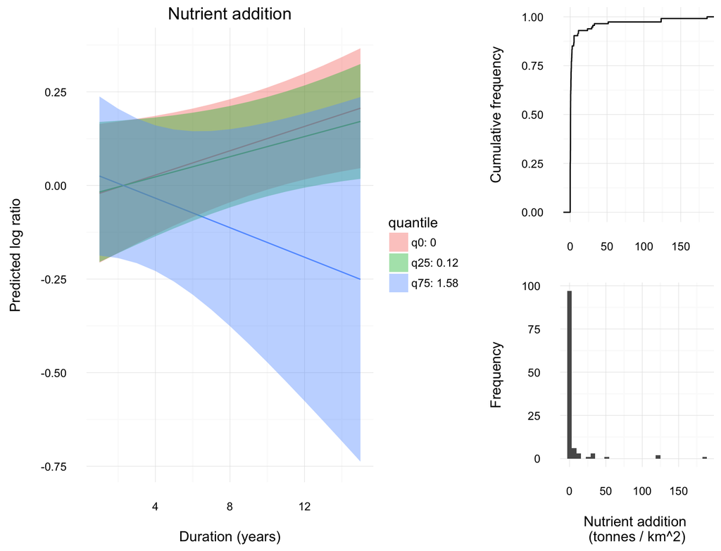

**Figure 8.** Predicted change in the log-proportion of change in species richness over time as moderated by nutrient addition over 15 years. Predictions were obtained using a variance-weighted meta-regression from the full drivers model: LR ~ Duration * (invasion potential + nutrient addition + linear temperature change). Invasion potential and linear temperature change were held constant at the median values of these two drivers found observed in our dataset. Shaded areas represent 95% confidence intervals. Cumulative frequency distributions (top right) and frequency histograms (bottom right) nutrient addition values observed in the data used for the variance-weighted meta-regression.

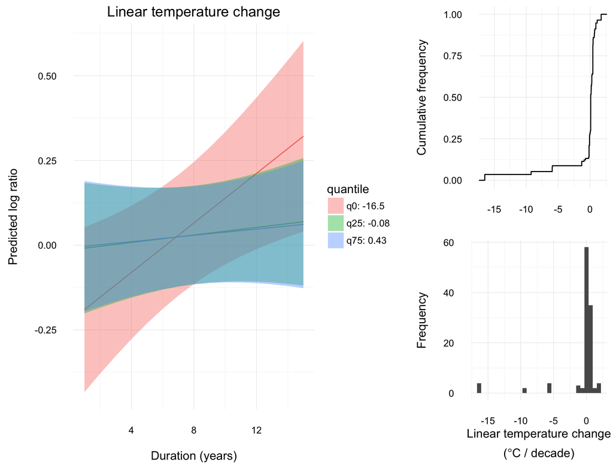

#### Driver interactions

Interactions between changing temperature and invasive species colonisation and changing temperature and nutrient addition have been predicted theoretically and are supported by observational (Sorte et al 2010 (invs), …) and experimental data (Binzer et al 2012 (nuts), …). We tested whether the effects of these interactions between temperature, propagule pressure, and nutrient addition were observed in our data. We did not observe an effect of these interactions in our data, however, this may be due to low power of using only studies (n = 24) that had sampling variances (Table 5).

**Table 4.** Standardised coefficient estimates from a variance-weighted meta-regression of the relationship between the log ratio of the proportion of species richness change (LR), study duration (D), and the interaction between drivers of biodiversity change: invasion potential (I), nutrient addition (N), and linear temperature change (LTC). To test how these three drivers affect the rate of change of species richness we included interactions between study duration and these three drivers. For each parameter estimate the standard error (se), p-value (pval), lower (ci.lb) and upper (ci.ub) 95% confidence intervals, number of sites (k) and number of studies (n) is included. The percent change (% change) has been back-calculated from the estimated log ratio of the proportion of change in species richness using raw (unscaled) predictor values. The units of this percent change are for each unit of driver impact level, except for the invasion potential, where the percent change is for each 10^3 increase in impact level. Each study could contain multiple sites and therefore studies were modeled as random effects.

| model | parameter | estimate | % change | se | pval | ci.lb | ci.ub | k | n |
| --- | --- | --- | --- | --- | --- | --- | --- | --- | --- |
| LR ~ D * (I * LTC + N * LTC) | intrcpt | -0.017 | -3.45 | 0.207 | 0.935 | -0.422 | 0.388 | 114 | 24 |
| LR ~ D * (I * LTC + N * LTC) | Duration | 0.024 | 1.66 | 0.014 | 0.098 | -0.004 | 0.052 | 114 | 24 |
| LR ~ D * (I * LTC + N * LTC) | Inv | -0.122 | -0.20 | 1.441 | 0.933 | -2.947 | 2.703 | 114 | 24 |
| LR ~ D * (I * LTC + N * LTC) | LTC | -0.331 | 0.75 | 0.314 | 0.292 | -0.946 | 0.285 | 114 | 24 |
| LR ~ D * (I * LTC + N * LTC) | Nut | 0.343 | 0.65 | 0.428 | 0.423 | -0.496 | 1.182 | 114 | 24 |
| LR ~ D * (I * LTC + N * LTC) | Inv:LTC | -3.351 | -1.23 | 2.288 | 0.143 | -7.836 | 1.134 | 114 | 24 |
| LR ~ D * (I * LTC + N * LTC) | LTC:Nut | 1.176 | 0.80 | 0.729 | 0.107 | -0.252 | 2.605 | 114 | 24 |
| LR ~ D * (I * LTC + N * LTC) | Duration:Inv | 0.114 | 0.10 | 0.102 | 0.263 | -0.086 | 0.313 | 114 | 24 |
| LR ~ D * (I * LTC + N * LTC) | Duration:LTC | -0.075 | -2.18 | 0.057 | 0.194 | -0.187 | 0.038 | 114 | 24 |
| LR ~ D * (I * LTC + N * LTC) | Duration:Nut | -0.098 | -0.17 | 0.052 | 0.058 | -0.200 | 0.003 | 114 | 24 |
| LR ~ D * (I * LTC + N * LTC) | Duration:Inv:LTC | -0.100 | -0.04 | 0.421 | 0.812 | -0.924 | 0.725 | 114 | 24 |
| LR ~ D * (I * LTC + N * LTC) | Duration:LTC:Nut | -0.039 | -0.03 | 0.142 | 0.783 | -0.318 | 0.240 | 114 | 24 |

#### Sample size weighted results summary

Unfortunately, the results from the variance-weighted meta-analysis differ from the results of both the sample size-weighted analysis and the unweighted analysis. In these sample size-weighted analyses, the number of replicates for each site was used as a proxy for precision of the species richness change estimate. Therefore, sites with higher replication had higher weights in the analysis. We did this because there were many studies for which there were no variances provided, which limited our sample size in the variance-weighted analysis. We triple our sample size by using a sample-size meta-regression (Table 5).

**Table 5.** Comparison of sample sizes used for each of the four models of the log ratio of species richness change performed using: variance-weighted (var-w) meta-regression, sample size-weighted (samp-w) meta-regression, and unweighted linear mixed effects regression (un-w).

| model | var-w sites | var-w studies | samp-w sites | samp-w studies | un-w sites | un-w studies |
| --- | --- | --- | --- | --- | --- | --- |
| LR ~ D | 148 | 36 | 506 | 115 | 506 | 115 |
| LR ~ D * Imp | 136 | 33 | 462 | 106 | 462 | 106 |
| LR ~ D * (I + N + LTC) | 114 | 24 | 383 | 85 | 383 | 85 |
| LR ~ D * (I * LTC + N * LTC) | 114 | 24 | 383 | 85 | 383 | 85 |

**Table 6.** Parameter estimates from a *sample size-weighted* meta-regression of the log ratio of the proportion of species richness change (LR) over study duration (D). For each parameter estimate the standard error (se), p-value (pval), lower (ci.lb) and upper (ci.ub) 95% confidence intervals, number of sites (k) and number of studies (n) is included. The percent change (% change) has been back-calculated from the estimated log ratio of the proportion of change in species richness. Each study could contain multiple sites and therefore studies were modeled as random effects.

| model | parameter | estimate | % change | se | pval | ci.lb | ci.ub | k | n |
| --- | --- | --- | --- | --- | --- | --- | --- | --- | --- |
| LR ~ D | intrcpt | 0.016 | 1.62 | 0.034 | 0.639 | -0.051 | 0.083 | 506 | 115 |
| LR ~ D | Duration | 0.004 | 0.37 | 0.002 | 0.082 | 0.000 | 0.008 | 506 | 115 |

**Table 7.** Parameter estimates from a *sample size-weighted* meta-regression of the relationship between the log ratio of the proportion of species richness change (LR), study duration (D), cumulative human impact value (Imp, Halpern et al. 2015), and the interaction of study duration and cumulative human impact value (D * Imp). For each parameter estimate the standard error (se), p-value (pval), lower (ci.lb) and upper (ci.ub) 95% confidence intervals, number of sites (k) and number of studies (n) is included. The percent change (% change) has been back-calculated from the parameter estimates of the log ratio of the proportion of change in species richness. Each study could contain multiple sites and therefore studies were modeled as random effects.

| model | parameter | estimate | % change | se | pval | ci.lb | ci.ub | k | n |
| --- | --- | --- | --- | --- | --- | --- | --- | --- | --- |
| LR ~ Imp + D + D*Imp | intrcpt | -0.129 | -12.09 | 0.130 | 0.320 | -0.383 | 0.126 | 462 | 106 |
| LR ~ Imp + D + D*Imp | Duration | -0.002 | -0.24 | 0.009 | 0.786 | -0.020 | 0.015 | 462 | 106 |
| LR ~ Imp + D + D*Imp | Impact | 0.034 | 3.51 | 0.033 | 0.291 | -0.030 | 0.099 | 462 | 106 |
| LR ~ Imp + D + D*Imp | Duration:Impact | 0.001 | 0.14 | 0.002 | 0.461 | -0.002 | 0.005 | 462 | 106 |

**Table 8.** Standardised coefficient estimates from a *sample size-weighted* meta-regression of the relationship between the log ratio of the proportion of species richness change (LR), study duration (D), and three drivers of biodiversity change: invasion potential (I), nutrient addition (N), and linear temperature change (LTC). To test how these three drivers affect the rate of change of species richness we included interactions between study duration and these three drivers. For each parameter estimate the standard error (se), p-value (pval), lower (ci.lb) and upper (ci.ub) 95% confidence intervals, number of sites (k) and number of studies (n) is included. The percent change (% change) has been back-calculated from the estimated log ratio of the proportion of change in species richness using raw (unscaled) predictor values. The units of this percent change are for each unit of driver impact level, except for the invasion potential, where the percent change is for each 10^3 increase in impact level. Each study could contain multiple sites and therefore studies were modeled as random effects.

| model | parameter | estimate | % change | se | pval | ci.lb | ci.ub | k | n |
| --- | --- | --- | --- | --- | --- | --- | --- | --- | --- |
| LR ~ D * (I + N + LTC) | intrcpt | 0.044 | 4.82 | 0.035 | 0.201 | -0.024 | 0.112 | 383 | 85 |
| LR ~ D * (I + N + LTC) | Duration | 0.000 | -0.08 | 0.003 | 0.873 | -0.006 | 0.007 | 383 | 85 |
| LR ~ D * (I + N + LTC) | Inv | 0.026 | 0.07 | 0.077 | 0.738 | -0.126 | 0.178 | 383 | 85 |
| LR ~ D * (I + N + LTC) | LTC | -0.031 | -1.27 | 0.037 | 0.404 | -0.103 | 0.042 | 383 | 85 |
| LR ~ D * (I + N + LTC) | Nut | -0.036 | -0.19 | 0.033 | 0.281 | -0.100 | 0.029 | 383 | 85 |
| LR ~ D * (I + N + LTC) | Duration:Inv | 0.003 | 0.01 | 0.011 | 0.780 | -0.018 | 0.024 | 383 | 85 |
| LR ~ D * (I + N + LTC) | Duration:LTC | 0.014 | 0.59 | 0.020 | 0.469 | -0.024 | 0.053 | 383 | 85 |
| LR ~ D * (I + N + LTC) | Duration:Nut | 0.007 | 0.04 | 0.004 | 0.086 | -0.001 | 0.014 | 383 | 85 |

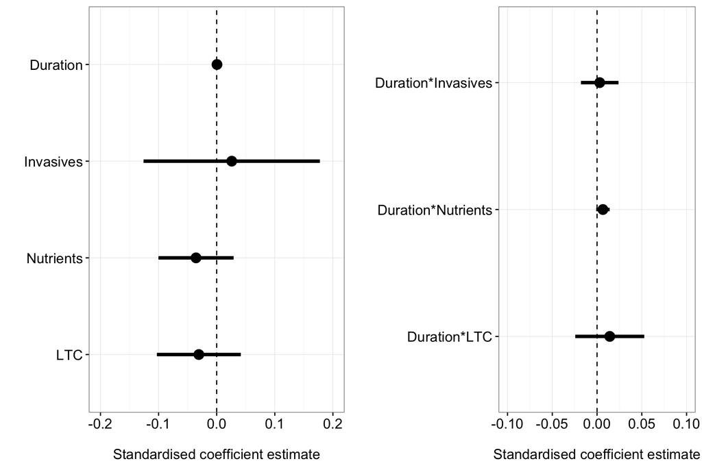

**Figure 10.** The relationship of the log-proportion of change in species richness over time, as moderated by three drivers of global change, invasives (propagule pressure), nutrient addition, and LTC (the decadal rate of linear temperature change). Points represent standardised coefficient estimates and lines represent 95% CI obtained using a sample size-weighted meta-regression.

**Table 9.** Standardised coefficient estimates from a *sample size-weighted* meta-regression of the relationship between the log ratio of the proportion of species richness change (LR), study duration (D), and the interaction between drivers of biodiversity change: invasion potential (I), nutrient addition (N), and linear temperature change (LTC). To test how these three drivers affect the rate of change of species richness we included interactions between study duration and these three drivers. For each parameter estimate the standard error (se), p-value (pval), lower (ci.lb) and upper (ci.ub) 95% confidence intervals, number of sites (k) and number of studies (n) is included. The percent change (% change) has been back-calculated from the estimated log ratio of the proportion of change in species richness using raw (unscaled) predictor values. The units of this percent change are for each unit of driver impact level, except for the invasion potential, where the percent change is for each 10^3 increase in impact level. Each study could contain multiple sites and therefore studies were modeled as random effects.

| model | parameter | estimate | % change | se | pval | ci.lb | ci.ub | k | n |
| --- | --- | --- | --- | --- | --- | --- | --- | --- | --- |
| LR ~ D * (I * LTC + N * LTC) | intrcpt | 0.082 | 6.49 | 0.065 | 0.207 | -0.046 | 0.210 | 383 | 85 |
| LR ~ D * (I * LTC + N * LTC) | Duration | -0.002 | -0.08 | 0.004 | 0.673 | -0.010 | 0.007 | 383 | 85 |
| LR ~ D * (I * LTC + N * LTC) | Inv | 0.293 | 0.73 | 0.428 | 0.494 | -0.549 | 1.135 | 383 | 85 |
| LR ~ D * (I * LTC + N * LTC) | LTC | -0.118 | -2.18 | 0.101 | 0.246 | -0.316 | 0.081 | 383 | 85 |
| LR ~ D * (I * LTC + N * LTC) | Nut | -0.106 | -0.55 | 0.087 | 0.221 | -0.277 | 0.064 | 383 | 85 |
| LR ~ D * (I * LTC + N * LTC) | Inv:LTC | -0.669 | -0.74 | 0.571 | 0.242 | -1.792 | 0.453 | 383 | 85 |
| LR ~ D * (I * LTC + N * LTC) | LTC:Nut | 0.127 | 0.29 | 0.160 | 0.428 | -0.188 | 0.442 | 383 | 85 |
| LR ~ D * (I * LTC + N * LTC) | Duration:Inv | -0.016 | -0.04 | 0.018 | 0.398 | -0.052 | 0.021 | 383 | 85 |
| LR ~ D * (I * LTC + N * LTC) | Duration:LTC | 0.018 | 0.36 | 0.022 | 0.410 | -0.025 | 0.061 | 383 | 85 |
| LR ~ D * (I * LTC + N * LTC) | Duration:Nut | 0.007 | 0.04 | 0.005 | 0.173 | -0.003 | 0.016 | 383 | 85 |
| LR ~ D * (I * LTC + N * LTC) | Duration:Inv:LTC | 0.053 | 0.06 | 0.079 | 0.505 | -0.103 | 0.209 | 383 | 85 |
| LR ~ D * (I * LTC + N * LTC) | Duration:LTC:Nut | 0.011 | 0.02 | 0.020 | 0.588 | -0.028 | 0.050 | 383 | 85 |

[figure not shown]

**Figure 11.** The relationship of the log-proportion of change in species richness over time, as moderated by three drivers and of global change, invasives (propagule pressure), nutrient addition, and LTC (the decadal rate of linear temperature change) and their interaction. Points represent standardised coefficient estimates and lines represent 95% CI obtained using a sample size-weighted meta-regression.

#### Unweighted results summary

**Table 10.** Parameter estimates from a linear mixed effects model (‘unweighted regression’) of the log ratio of the proportion of species richness change (LR) over study duration (D). For each parameter estimate the standard error (se), p-value (pval), lower (ci.lb) and upper (ci.ub) 95% confidence intervals, number of sites (k) and number of studies (n) is included. The percent change (% change) has been back-calculated from the estimated log ratio of the proportion of change in species richness. Each study could contain multiple sites and therefore studies were modeled as random effects.

| model | parameter | estimate | % change | se | pval | ci.lb | ci.ub | k | n |
| --- | --- | --- | --- | --- | --- | --- | --- | --- | --- |
| LR ~ D | (Intercept) | -0.013 | -1.32 | 0.042 | 0.754 | -0.096 | 0.070 | 506 | 115 |
| LR ~ D | Duration | 0.004 | 0.38 | 0.003 | 0.151 | -0.001 | 0.009 | 506 | 115 |

**Table 11.** Standardised coefficient estimates from a linear mixed effects model (‘unweighted regression’) of the relationship between the log ratio of the proportion of species richness change (LR), study duration (D), cumulative human impact value (Imp, Halpern et al. 2015), and the interaction of study duration and cumulative human impact value (D * Imp). For each parameter estimate the standard error (se), p-value (pval), lower (ci.lb) and upper (ci.ub) 95% confidence intervals, number of sites (k) and number of studies (n) is included. The percent change (% change) has been back-calculated from the parameter estimates of the log ratio of the proportion of change in species richness. Each study could contain multiple sites and therefore studies were modeled as random effects.

| model | parameter | estimate | % change | se | pval | ci.lb | ci.ub | k | n |
| --- | --- | --- | --- | --- | --- | --- | --- | --- | --- |
| LR ~ Imp + D + D*Imp | (Intercept) | -0.215 | -19.32 | 0.113 | 0.059 | -0.435 | 0.006 | 462 | 106 |
| LR ~ Imp + D + D*Imp | Duration | 0.011 | 1.09 | 0.006 | 0.067 | -0.001 | 0.023 | 462 | 106 |
| LR ~ Imp + D + D*Imp | Impact | 0.044 | 4.53 | 0.024 | 0.064 | -0.002 | 0.091 | 462 | 106 |
| LR ~ Imp + D + D*Imp | Duration:Impact | -0.002 | -0.15 | 0.001 | 0.206 | -0.004 | 0.001 | 462 | 106 |

**Table 12.** Standardised coefficient estimates from a linear mixed effects model (‘unweighted regression’) of the relationship between the log ratio of the proportion of species richness change (LR), study duration (D), and the interaction between drivers of biodiversity change: invasion potential (I), nutrient addition (N), and linear temperature change (LTC). To test how these three drivers affect the rate of change of species richness we included interactions between study duration and these three drivers. For each parameter estimate the standard error (se), p-value (pval), lower (ci.lb) and upper (ci.ub) 95% confidence intervals, number of sites (k) and number of studies (n) is included. The percent change (% change) has been back-calculated from the estimated log ratio of the proportion of change in species richness using raw (unscaled) predictor values. The units of this percent change are for each unit of driver impact level, except for the invasion potential, where the percent change is for each 10^3 increase in impact level. Each study could contain multiple sites and therefore studies were modeled as random effects.

| model | parameter | estimate | % change | se | pval | ci.lb | ci.ub | k | n |
| --- | --- | --- | --- | --- | --- | --- | --- | --- | --- |
| LR ~ D * (I + N + LTC) | (Intercept | 0.007 | 0.35 | 0.050 | 0.882 | -0.088 | 0.104 | 383 | 85 |
| LR ~ D * (I + N + LTC) | Duration | 0.004 | 0.18 | 0.004 | 0.280 | -0.003 | 0.012 | 383 | 85 |
| LR ~ D * (I + N + LTC) | Inv | 0.033 | 0.03 | 0.177 | 0.852 | -0.312 | 0.374 | 383 | 85 |
| LR ~ D * (I + N + LTC) | LTC | 0.003 | 0.12 | 0.037 | 0.934 | -0.069 | 0.074 | 383 | 85 |
| LR ~ D * (I + N + LTC) | Nut | -0.007 | -0.01 | 0.126 | 0.958 | -0.251 | 0.235 | 383 | 85 |
| LR ~ D * (I + N + LTC) | Duration:Inv | 0.016 | 0.02 | 0.018 | 0.359 | -0.018 | 0.051 | 383 | 85 |
| LR ~ D * (I + N + LTC) | Duration:LTC | 0.009 | 0.37 | 0.019 | 0.616 | -0.027 | 0.046 | 383 | 85 |
| LR ~ D * (I + N + LTC) | Duration:Nut | 0.004 | 0.01 | 0.012 | 0.755 | -0.019 | 0.026 | 383 | 85 |

**Table 13.** Standardised coefficient estimates from a linear mixed effects model (‘unweighted regression’) of the relationship between the log ratio of the proportion of species richness change (LR), study duration (D), and the interaction between drivers of biodiversity change: invasion potential (I), nutrient addition (N), and linear temperature change (LTC). To test how these three drivers affect the rate of change of species richness we included interactions between study duration and these three drivers. For each parameter estimate the standard error (se), p-value (pval), lower (ci.lb) and upper (ci.ub) 95% confidence intervals, number of sites (k) and number of studies (n) is included. The percent change (% change) has been back-calculated from the estimated log ratio of the proportion of change in species richness using raw (unscaled) predictor values. The units of this percent change are for each unit of driver impact level, except for the invasion potential, where the percent change is for each 10^3 increase in impact level. Each study could contain multiple sites and therefore studies were modeled as random effects.

| model | parameter | estimate | % change | se | pval | ci.lb | ci.ub | k | n |
| --- | --- | --- | --- | --- | --- | --- | --- | --- | --- |
| LR ~ D * (I + N + LTC) | (Intercept | -0.003 | 1.69 | 0.084 | 0.969 | -0.167 | 0.157 | 383 | 85 |
| LR ~ D * (I + N + LTC) | Duration | 0.003 | 0.19 | 0.005 | 0.520 | -0.006 | 0.012 | 383 | 85 |
| LR ~ D * (I + N + LTC) | Inv | -0.086 | -0.09 | 0.606 | 0.888 | -1.286 | 1.063 | 383 | 85 |
| LR ~ D * (I + N + LTC) | LTC | -0.047 | 1.05 | 0.100 | 0.637 | -0.240 | 0.146 | 383 | 85 |
| LR ~ D * (I + N + LTC) | Nut | -0.068 | -0.13 | 0.219 | 0.757 | -0.484 | 0.354 | 383 | 85 |
| LR ~ D * (I + N + LTC) | Inv:LTC | -0.385 | -0.14 | 0.684 | 0.574 | -1.704 | 0.940 | 383 | 85 |
| LR ~ D * (I + N + LTC) | LTC:Nut | -0.185 | -0.12 | 0.190 | 0.332 | -0.550 | 0.178 | 383 | 85 |
| LR ~ D * (I + N + LTC) | Duration:Inv | 0.014 | 0.01 | 0.025 | 0.583 | -0.034 | 0.063 | 383 | 85 |
| LR ~ D * (I + N + LTC) | Duration:LTC | 0.022 | 0.05 | 0.026 | 0.388 | -0.027 | 0.073 | 383 | 85 |
| LR ~ D * (I + N + LTC) | Duration:Nut | -0.008 | -0.01 | 0.017 | 0.645 | -0.040 | 0.024 | 383 | 85 |
| LR ~ D * (I + N + LTC) | Duration:Inv:LTC | 0.069 | 0.03 | 0.163 | 0.674 | -0.242 | 0.390 | 383 | 85 |
| LR ~ D * (I + N + LTC) | Duration:LTC:Nut | 0.108 | 0.07 | 0.095 | 0.257 | -0.075 | 0.288 | 383 | 85 |